# Risk Factor Analysis

## Outcome Variable

**Outcome Variable:** stunted

## Predictor Variables

**Intervention Variable:** nchldlt5

**Adjustment Set:**

unadjusted

## Stratifying Variables

The analysis was stratified on these variable(s):

- agecat
- studyid
- country

## Data Summary

| agecat | studyid | country | nchldlt5 | stunted | n_cell | n |
| --- | --- | --- | --- | --- | --- | --- |
| 6 months | ki1000108-IRC | INDIA | 1 | 0 | 67 | 407 |
| 6 months | ki1000108-IRC | INDIA | 1 | 1 | 22 | 407 |
| 6 months | ki1000108-IRC | INDIA | 2 | 0 | 90 | 407 |
| 6 months | ki1000108-IRC | INDIA | 2 | 1 | 29 | 407 |
| 6 months | ki1000108-IRC | INDIA | 3+ | 0 | 150 | 407 |
| 6 months | ki1000108-IRC | INDIA | 3+ | 1 | 49 | 407 |
| 24 months | ki1000108-IRC | INDIA | 1 | 0 | 58 | 409 |
| 24 months | ki1000108-IRC | INDIA | 1 | 1 | 31 | 409 |
| 24 months | ki1000108-IRC | INDIA | 2 | 0 | 73 | 409 |
| 24 months | ki1000108-IRC | INDIA | 2 | 1 | 46 | 409 |
| 24 months | ki1000108-IRC | INDIA | 3+ | 0 | 108 | 409 |
| 24 months | ki1000108-IRC | INDIA | 3+ | 1 | 93 | 409 |
| Birth | ki1000108-IRC | INDIA | 1 | 0 | 72 | 388 |
| Birth | ki1000108-IRC | INDIA | 1 | 1 | 12 | 388 |
| Birth | ki1000108-IRC | INDIA | 2 | 0 | 100 | 388 |
| Birth | ki1000108-IRC | INDIA | 2 | 1 | 14 | 388 |
| Birth | ki1000108-IRC | INDIA | 3+ | 0 | 171 | 388 |
| Birth | ki1000108-IRC | INDIA | 3+ | 1 | 19 | 388 |
| 6 months | ki1017093b-PROVIDE | BANGLADESH | 1 | 0 | 357 | 583 |
| 6 months | ki1017093b-PROVIDE | BANGLADESH | 1 | 1 | 69 | 583 |
| 6 months | ki1017093b-PROVIDE | BANGLADESH | 2 | 0 | 124 | 583 |
| 6 months | ki1017093b-PROVIDE | BANGLADESH | 2 | 1 | 24 | 583 |
| 6 months | ki1017093b-PROVIDE | BANGLADESH | 3+ | 0 | 8 | 583 |
| 6 months | ki1017093b-PROVIDE | BANGLADESH | 3+ | 1 | 1 | 583 |
| 24 months | ki1017093b-PROVIDE | BANGLADESH | 1 | 0 | 298 | 577 |
| 24 months | ki1017093b-PROVIDE | BANGLADESH | 1 | 1 | 125 | 577 |
| 24 months | ki1017093b-PROVIDE | BANGLADESH | 2 | 0 | 83 | 577 |
| 24 months | ki1017093b-PROVIDE | BANGLADESH | 2 | 1 | 63 | 577 |
| 24 months | ki1017093b-PROVIDE | BANGLADESH | 3+ | 0 | 6 | 577 |
| 24 months | ki1017093b-PROVIDE | BANGLADESH | 3+ | 1 | 2 | 577 |

[output cut: 58 more lines]

The following strata were considered:

- agecat: 24 months, studyid: ki1000108-IRC, country: INDIA
- agecat: 24 months, studyid: ki1017093b-PROVIDE, country: BANGLADESH
- agecat: 24 months, studyid: ki1017093c-NIH-Crypto, country: BANGLADESH
- agecat: 24 months, studyid: ki1066203-TanzaniaChild2, country: TANZANIA, UNITED REPUBLIC OF
- agecat: 24 months, studyid: ki1148112-LCNI-5, country: MALAWI
- agecat: 24 months, studyid: kiGH5241-JiVitA-3, country: BANGLADESH
- agecat: 6 months, studyid: ki1000108-IRC, country: INDIA
- agecat: 6 months, studyid: ki1017093b-PROVIDE, country: BANGLADESH
- agecat: 6 months, studyid: ki1017093c-NIH-Crypto, country: BANGLADESH
- agecat: 6 months, studyid: ki1066203-TanzaniaChild2, country: TANZANIA, UNITED REPUBLIC OF
- agecat: 6 months, studyid: ki1148112-LCNI-5, country: MALAWI
- agecat: 6 months, studyid: kiGH5241-JiVitA-3, country: BANGLADESH
- agecat: Birth, studyid: ki1000108-IRC, country: INDIA
- agecat: Birth, studyid: ki1017093c-NIH-Crypto, country: BANGLADESH
- agecat: Birth, studyid: kiGH5241-JiVitA-3, country: BANGLADESH

### Dropped Strata

- agecat: 6 months, studyid: ki1017093b-PROVIDE, country: BANGLADESH
- agecat: 24 months, studyid: ki1017093b-PROVIDE, country: BANGLADESH
- agecat: Birth, studyid: ki1017093c-NIH-Crypto, country: BANGLADESH
- agecat: 6 months, studyid: ki1017093c-NIH-Crypto, country: BANGLADESH
- agecat: 24 months, studyid: ki1017093c-NIH-Crypto, country: BANGLADESH
- agecat: 24 months, studyid: ki1066203-TanzaniaChild2, country: TANZANIA, UNITED REPUBLIC OF

## Methods Detail

We’re interested in the causal parameters $E[Y_a]$ for all values of $a \in \mathcal{A}$. These parameters represent the mean outcome if, possibly contrary to fact, we intervened to set all units to have $A=a$. Under the randomization and positivity assumptions, these are identified by the statistical parameters $\psi_a=E_W[E_{Y|A,W}(Y|A=a,W)]$. In addition, we’re interested in the mean of $Y$, $E[Y]$ under no intervention (the observed mean). We will estimate these parameters by using SuperLearner to fit the relevant likelihood factors – $E_{Y|A,W}(Y|A=a,W)$ and $p(A=a|W)$, and then updating our likelihood fit using a joint TMLE.

For unadjusted analyses ($W=\{\}$), initial likelihoods were estimated using Lrnr_glm to estimate the simple $E(Y|A)$ and Lrnr_mean to estimate $p(A)$. For adjusted analyses, a small library containing Lrnr_glmnet, Lrnr_xgboost, and Lrnr_mean was used.

Having estimated these parameters, we will then use the delta method to estimate relative risks and attributable risks relative to a prespecified baseline level of $A$.

# Results Detail

## Results Plots

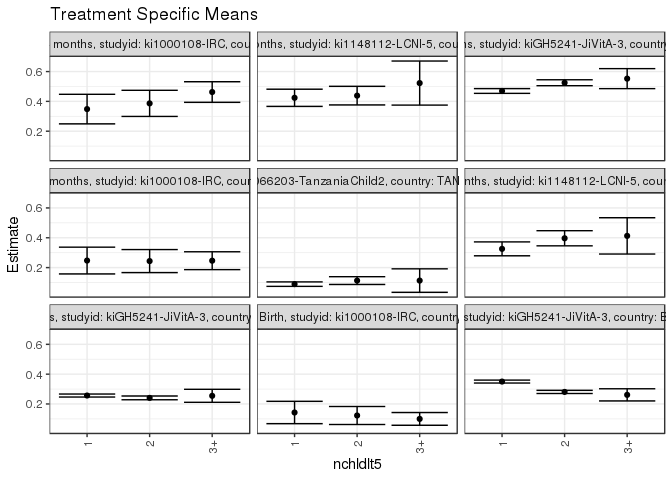

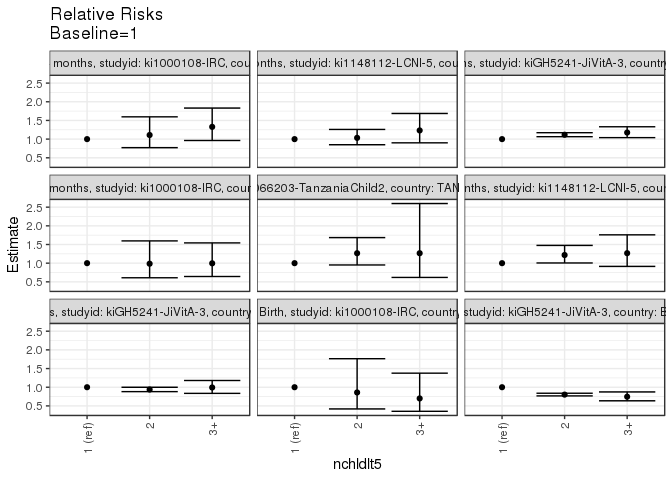

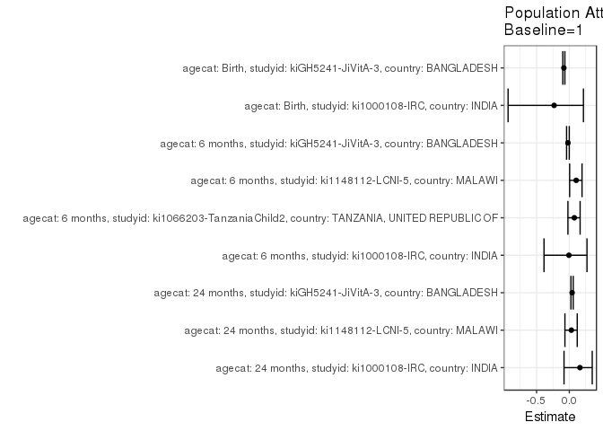

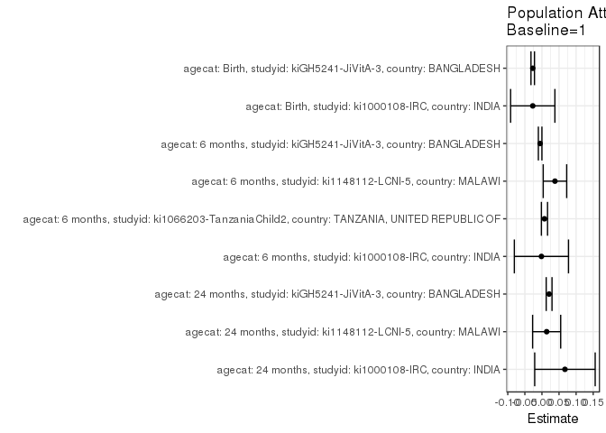

## Results Table

### Parameter: TSM

| agecat | studyid | country | intervention_level | baseline_level | estimate | ci_lower | ci_upper |
| --- | --- | --- | --- | --- | --- | --- | --- |
| Birth | ki1000108-IRC | INDIA | 1 | NA | 0.1428571 | 0.0679288 | 0.2177855 |
| Birth | ki1000108-IRC | INDIA | 2 | NA | 0.1228070 | 0.0624795 | 0.1831345 |
| Birth | ki1000108-IRC | INDIA | 3+ | NA | 0.1000000 | 0.0572877 | 0.1427123 |
| Birth | kiGH5241-JiVitA-3 | BANGLADESH | 1 | NA | 0.3502148 | 0.3403302 | 0.3600994 |
| Birth | kiGH5241-JiVitA-3 | BANGLADESH | 2 | NA | 0.2809117 | 0.2702721 | 0.2915513 |
| Birth | kiGH5241-JiVitA-3 | BANGLADESH | 3+ | NA | 0.2612420 | 0.2204350 | 0.3020490 |
| 6 months | ki1000108-IRC | INDIA | 1 | NA | 0.2471910 | 0.1574593 | 0.3369227 |
| 6 months | ki1000108-IRC | INDIA | 2 | NA | 0.2436975 | 0.1664682 | 0.3209268 |
| 6 months | ki1000108-IRC | INDIA | 3+ | NA | 0.2462312 | 0.1863009 | 0.3061614 |
| 6 months | ki1066203-TanzaniaChild2 | TANZANIA, UNITED REPUBLIC OF | 1 | NA | 0.0891445 | 0.0741661 | 0.1041229 |
| 6 months | ki1066203-TanzaniaChild2 | TANZANIA, UNITED REPUBLIC OF | 2 | NA | 0.1128748 | 0.0868219 | 0.1389276 |
| 6 months | ki1066203-TanzaniaChild2 | TANZANIA, UNITED REPUBLIC OF | 3+ | NA | 0.1129032 | 0.0341083 | 0.1916982 |
| 6 months | ki1148112-LCNI-5 | MALAWI | 1 | NA | 0.3256410 | 0.2791040 | 0.3721781 |
| 6 months | ki1148112-LCNI-5 | MALAWI | 2 | NA | 0.3966480 | 0.3459417 | 0.4473544 |
| 6 months | ki1148112-LCNI-5 | MALAWI | 3+ | NA | 0.4126984 | 0.2910538 | 0.5343430 |
| 6 months | kiGH5241-JiVitA-3 | BANGLADESH | 1 | NA | 0.2566364 | 0.2466681 | 0.2666046 |
| 6 months | kiGH5241-JiVitA-3 | BANGLADESH | 2 | NA | 0.2408075 | 0.2281365 | 0.2534785 |
| 6 months | kiGH5241-JiVitA-3 | BANGLADESH | 3+ | NA | 0.2547945 | 0.2111767 | 0.2984124 |
| 24 months | ki1000108-IRC | INDIA | 1 | NA | 0.3483146 | 0.2492110 | 0.4474182 |
| 24 months | ki1000108-IRC | INDIA | 2 | NA | 0.3865546 | 0.2989555 | 0.4741537 |
| 24 months | ki1000108-IRC | INDIA | 3+ | NA | 0.4626866 | 0.3936723 | 0.5317008 |
| 24 months | ki1148112-LCNI-5 | MALAWI | 1 | NA | 0.4240283 | 0.3664003 | 0.4816563 |
| 24 months | ki1148112-LCNI-5 | MALAWI | 2 | NA | 0.4385246 | 0.3762091 | 0.5008401 |
| 24 months | ki1148112-LCNI-5 | MALAWI | 3+ | NA | 0.5227273 | 0.3750127 | 0.6704418 |
| 24 months | kiGH5241-JiVitA-3 | BANGLADESH | 1 | NA | 0.4697470 | 0.4537388 | 0.4857552 |
| 24 months | kiGH5241-JiVitA-3 | BANGLADESH | 2 | NA | 0.5249237 | 0.5050510 | 0.5447964 |
| 24 months | kiGH5241-JiVitA-3 | BANGLADESH | 3+ | NA | 0.5525114 | 0.4854338 | 0.6195890 |

### Parameter: E(Y)

| agecat | studyid | country | intervention_level | baseline_level | estimate | ci_lower | ci_upper |
| --- | --- | --- | --- | --- | --- | --- | --- |
| Birth | ki1000108-IRC | INDIA | NA | NA | 0.1159794 | 0.0840777 | 0.1478811 |
| Birth | kiGH5241-JiVitA-3 | BANGLADESH | NA | NA | 0.3232607 | 0.3156042 | 0.3309171 |
| 6 months | ki1000108-IRC | INDIA | NA | NA | 0.2457002 | 0.2038248 | 0.2875757 |
| 6 months | ki1066203-TanzaniaChild2 | TANZANIA, UNITED REPUBLIC OF | NA | NA | 0.0965347 | 0.0836528 | 0.1094165 |
| 6 months | ki1148112-LCNI-5 | MALAWI | NA | NA | 0.3637485 | 0.3306185 | 0.3968784 |
| 6 months | kiGH5241-JiVitA-3 | BANGLADESH | NA | NA | 0.2513690 | 0.2432434 | 0.2594947 |
| 24 months | ki1000108-IRC | INDIA | NA | NA | 0.4156479 | 0.3678270 | 0.4634689 |
| 24 months | ki1148112-LCNI-5 | MALAWI | NA | NA | 0.4378284 | 0.3971000 | 0.4785567 |
| 24 months | kiGH5241-JiVitA-3 | BANGLADESH | NA | NA | 0.4907214 | 0.4775947 | 0.5038481 |

### Parameter: RR

| agecat | studyid | country | intervention_level | baseline_level | estimate | ci_lower | ci_upper |
| --- | --- | --- | --- | --- | --- | --- | --- |
| Birth | ki1000108-IRC | INDIA | 1 | 1 | 1.0000000 | 1.0000000 | 1.0000000 |
| Birth | ki1000108-IRC | INDIA | 2 | 1 | 0.8596491 | 0.4190143 | 1.7636551 |
| Birth | ki1000108-IRC | INDIA | 3+ | 1 | 0.7000000 | 0.3559067 | 1.3767655 |
| Birth | kiGH5241-JiVitA-3 | BANGLADESH | 1 | 1 | 1.0000000 | 1.0000000 | 1.0000000 |
| Birth | kiGH5241-JiVitA-3 | BANGLADESH | 2 | 1 | 0.8021125 | 0.7671027 | 0.8387202 |
| Birth | kiGH5241-JiVitA-3 | BANGLADESH | 3+ | 1 | 0.7459478 | 0.6367353 | 0.8738924 |
| 6 months | ki1000108-IRC | INDIA | 1 | 1 | 1.0000000 | 1.0000000 | 1.0000000 |
| 6 months | ki1000108-IRC | INDIA | 2 | 1 | 0.9858671 | 0.6088959 | 1.5962234 |
| 6 months | ki1000108-IRC | INDIA | 3+ | 1 | 0.9961169 | 0.6434315 | 1.5421206 |
| 6 months | ki1066203-TanzaniaChild2 | TANZANIA, UNITED REPUBLIC OF | 1 | 1 | 1.0000000 | 1.0000000 | 1.0000000 |
| 6 months | ki1066203-TanzaniaChild2 | TANZANIA, UNITED REPUBLIC OF | 2 | 1 | 1.2662001 | 0.9517318 | 1.6845742 |
| 6 months | ki1066203-TanzaniaChild2 | TANZANIA, UNITED REPUBLIC OF | 3+ | 1 | 1.2665193 | 0.6178144 | 2.5963641 |
| 6 months | ki1148112-LCNI-5 | MALAWI | 1 | 1 | 1.0000000 | 1.0000000 | 1.0000000 |
| 6 months | ki1148112-LCNI-5 | MALAWI | 2 | 1 | 1.2180531 | 1.0055260 | 1.4754996 |
| 6 months | ki1148112-LCNI-5 | MALAWI | 3+ | 1 | 1.2673416 | 0.9133374 | 1.7585557 |
| 6 months | kiGH5241-JiVitA-3 | BANGLADESH | 1 | 1 | 1.0000000 | 1.0000000 | 1.0000000 |
| 6 months | kiGH5241-JiVitA-3 | BANGLADESH | 2 | 1 | 0.9383218 | 0.8817736 | 0.9984965 |
| 6 months | kiGH5241-JiVitA-3 | BANGLADESH | 3+ | 1 | 0.9928232 | 0.8352742 | 1.1800890 |
| 24 months | ki1000108-IRC | INDIA | 1 | 1 | 1.0000000 | 1.0000000 | 1.0000000 |
| 24 months | ki1000108-IRC | INDIA | 2 | 1 | 1.1097858 | 0.7713798 | 1.5966514 |
| 24 months | ki1000108-IRC | INDIA | 3+ | 1 | 1.3283582 | 0.9633801 | 1.8316088 |
| 24 months | ki1148112-LCNI-5 | MALAWI | 1 | 1 | 1.0000000 | 1.0000000 | 1.0000000 |
| 24 months | ki1148112-LCNI-5 | MALAWI | 2 | 1 | 1.0341872 | 0.8495785 | 1.2589102 |
| 24 months | ki1148112-LCNI-5 | MALAWI | 3+ | 1 | 1.2327652 | 0.9009483 | 1.6867893 |
| 24 months | kiGH5241-JiVitA-3 | BANGLADESH | 1 | 1 | 1.0000000 | 1.0000000 | 1.0000000 |
| 24 months | kiGH5241-JiVitA-3 | BANGLADESH | 2 | 1 | 1.1174605 | 1.0651215 | 1.1723715 |
| 24 months | kiGH5241-JiVitA-3 | BANGLADESH | 3+ | 1 | 1.1761894 | 1.0399286 | 1.3303044 |

### Parameter: PAR

| agecat | studyid | country | intervention_level | baseline_level | estimate | ci_lower | ci_upper |
| --- | --- | --- | --- | --- | --- | --- | --- |
| Birth | ki1000108-IRC | INDIA | 1 | NA | -0.0268778 | -0.0916934 | 0.0379379 |
| Birth | kiGH5241-JiVitA-3 | BANGLADESH | 1 | NA | -0.0269541 | -0.0320902 | -0.0218181 |
| 6 months | ki1000108-IRC | INDIA | 1 | NA | -0.0014908 | -0.0807619 | 0.0777804 |
| 6 months | ki1066203-TanzaniaChild2 | TANZANIA, UNITED REPUBLIC OF | 1 | NA | 0.0073902 | -0.0016270 | 0.0164074 |
| 6 months | ki1148112-LCNI-5 | MALAWI | 1 | NA | 0.0381074 | 0.0037508 | 0.0724640 |
| 6 months | kiGH5241-JiVitA-3 | BANGLADESH | 1 | NA | -0.0052673 | -0.0104675 | -0.0000671 |
| 24 months | ki1000108-IRC | INDIA | 1 | NA | 0.0673333 | -0.0211764 | 0.1558430 |
| 24 months | ki1148112-LCNI-5 | MALAWI | 1 | NA | 0.0138001 | -0.0272837 | 0.0548839 |
| 24 months | kiGH5241-JiVitA-3 | BANGLADESH | 1 | NA | 0.0209744 | 0.0124722 | 0.0294767 |

### Parameter: PAF

| agecat | studyid | country | intervention_level | baseline_level | estimate | ci_lower | ci_upper |
| --- | --- | --- | --- | --- | --- | --- | --- |
| Birth | ki1000108-IRC | INDIA | 1 | NA | -0.2317460 | -0.9350634 | 0.2159439 |
| Birth | kiGH5241-JiVitA-3 | BANGLADESH | 1 | NA | -0.0833820 | -0.0991870 | -0.0678043 |
| 6 months | ki1000108-IRC | INDIA | 1 | NA | -0.0060674 | -0.3864361 | 0.2699471 |
| 6 months | ki1066203-TanzaniaChild2 | TANZANIA, UNITED REPUBLIC OF | 1 | NA | 0.0765544 | -0.0212450 | 0.1649881 |
| 6 months | ki1148112-LCNI-5 | MALAWI | 1 | NA | 0.1047631 | 0.0051365 | 0.1944131 |
| 6 months | kiGH5241-JiVitA-3 | BANGLADESH | 1 | NA | -0.0209545 | -0.0418128 | -0.0005138 |
| 24 months | ki1000108-IRC | INDIA | 1 | NA | 0.1619960 | -0.0806502 | 0.3501592 |
| 24 months | ki1148112-LCNI-5 | MALAWI | 1 | NA | 0.0315194 | -0.0670380 | 0.1209735 |
| 24 months | kiGH5241-JiVitA-3 | BANGLADESH | 1 | NA | 0.0427420 | 0.0251592 | 0.0600077 |